# Plant Phenological Responses to Climate Change

latif003 and tziol001

Friday, January 30, 2015

# Introduction

Phenology: *the study of the timing of recurring biological cycles and their connection to climate providing society with an independent measure on how ecosystems are responding to climate change (White, M., et al. 2009)*

- Forestry: to monitor carbon levels at atmosphere
- Natural resources management (water and timber)
- Agriculture: planting and harvesting time, pest control
- Understanding hazard: monitoring and prediction of drought and fire risk

# Introduction

**Greenup date**

*when green leaves are first detected in spring*

Factors influencing plant phenology:

- precipitation
- temperature

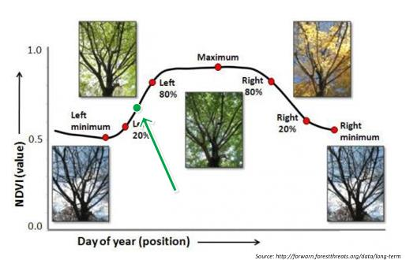

# Study area

*Lelystad, the Netherlands*  
- Broadleaves forest  
- sufficiently large area for MODIS satellite imagery  
- continuous data availability

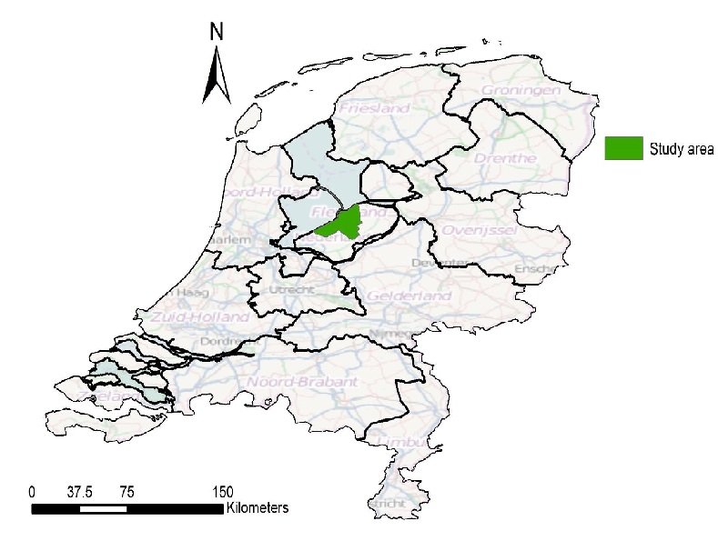

# Material and methods

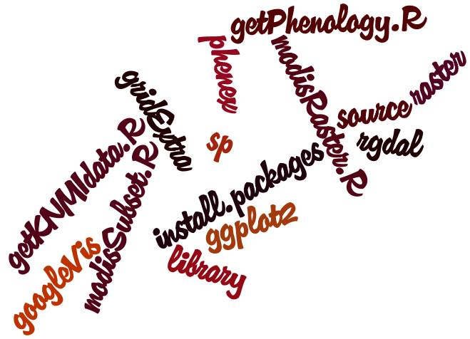

# Material and methods

- Flowchart

[figure not shown]

# Download data

- MODIS subset

ndvi_clear13 <- **modisSubset**(“Lelystad”, “NDVI”, 2013, rel = TRUE)

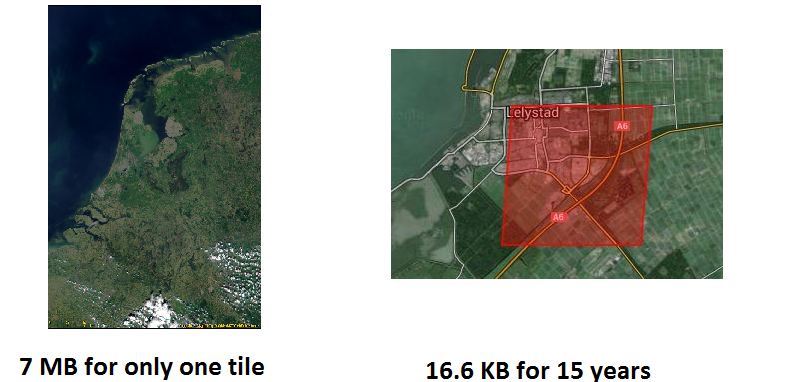

- Meteorogical data

meteo <- **getKNMIdata**(269)

# Preprocessing

Comparison of cummulative values

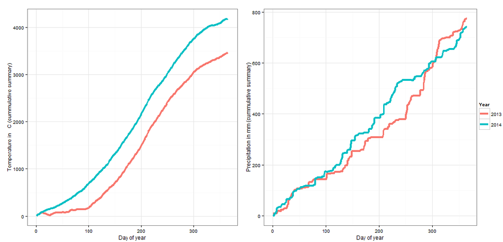

**Are the greenup date affected by the differences in weather between 2013 and 2014?**

# Preprocessing

From .txt to Raster!

stack_2013 <- **modisRaster**(ndvi_clear13,“Lelystad”)

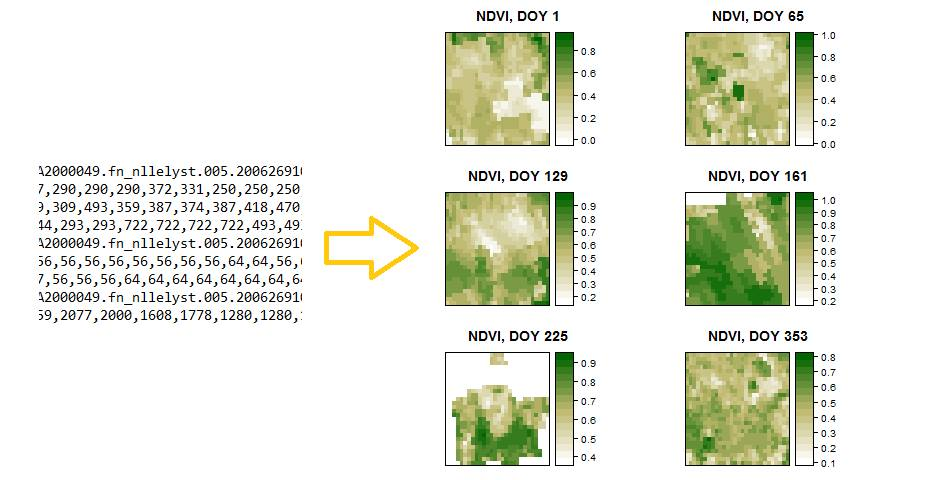